# Risk Factor Analysis

## Outcome Variable

**Outcome Variable:** pers_wast

## Predictor Variables

**Intervention Variable:** hdlvry

**Adjustment Set:**

unadjusted

## Stratifying Variables

The analysis was stratified on these variable(s):

- agecat
- studyid
- country

## Data Summary

| agecat | studyid | country | hdlvry | pers_wast | n_cell | n |
| --- | --- | --- | --- | --- | --- | --- |
| 0-24 months | ki1000108-CMC-V-BCS-2002 | INDIA | 0 | 0 | 339 | 370 |
| 0-24 months | ki1000108-CMC-V-BCS-2002 | INDIA | 0 | 1 | 23 | 370 |
| 0-24 months | ki1000108-CMC-V-BCS-2002 | INDIA | 1 | 0 | 8 | 370 |
| 0-24 months | ki1000108-CMC-V-BCS-2002 | INDIA | 1 | 1 | 0 | 370 |
| 0-24 months | ki1000108-IRC | INDIA | 0 | 0 | 354 | 410 |
| 0-24 months | ki1000108-IRC | INDIA | 0 | 1 | 48 | 410 |
| 0-24 months | ki1000108-IRC | INDIA | 1 | 0 | 8 | 410 |
| 0-24 months | ki1000108-IRC | INDIA | 1 | 1 | 0 | 410 |
| 0-24 months | ki1000109-EE | PAKISTAN | 0 | 0 | 235 | 375 |
| 0-24 months | ki1000109-EE | PAKISTAN | 0 | 1 | 17 | 375 |
| 0-24 months | ki1000109-EE | PAKISTAN | 1 | 0 | 113 | 375 |
| 0-24 months | ki1000109-EE | PAKISTAN | 1 | 1 | 10 | 375 |
| 0-24 months | ki1000304b-SAS-CompFeed | INDIA | 0 | 0 | 142 | 1116 |
| 0-24 months | ki1000304b-SAS-CompFeed | INDIA | 0 | 1 | 9 | 1116 |
| 0-24 months | ki1000304b-SAS-CompFeed | INDIA | 1 | 0 | 872 | 1116 |
| 0-24 months | ki1000304b-SAS-CompFeed | INDIA | 1 | 1 | 93 | 1116 |
| 0-24 months | ki1000304b-SAS-FoodSuppl | INDIA | 0 | 0 | 64 | 375 |
| 0-24 months | ki1000304b-SAS-FoodSuppl | INDIA | 0 | 1 | 10 | 375 |
| 0-24 months | ki1000304b-SAS-FoodSuppl | INDIA | 1 | 0 | 246 | 375 |
| 0-24 months | ki1000304b-SAS-FoodSuppl | INDIA | 1 | 1 | 55 | 375 |
| 0-24 months | ki1017093b-PROVIDE | BANGLADESH | 0 | 0 | 469 | 640 |
| 0-24 months | ki1017093b-PROVIDE | BANGLADESH | 0 | 1 | 10 | 640 |
| 0-24 months | ki1017093b-PROVIDE | BANGLADESH | 1 | 0 | 156 | 640 |
| 0-24 months | ki1017093b-PROVIDE | BANGLADESH | 1 | 1 | 5 | 640 |
| 0-24 months | ki1017093c-NIH-Crypto | BANGLADESH | 0 | 0 | 551 | 730 |
| 0-24 months | ki1017093c-NIH-Crypto | BANGLADESH | 0 | 1 | 16 | 730 |
| 0-24 months | ki1017093c-NIH-Crypto | BANGLADESH | 1 | 0 | 153 | 730 |
| 0-24 months | ki1017093c-NIH-Crypto | BANGLADESH | 1 | 1 | 10 | 730 |
| 0-24 months | ki1066203-TanzaniaChild2 | TANZANIA, UNITED REPUBLIC OF | 0 | 0 | 1966 | 2056 |
| 0-24 months | ki1066203-TanzaniaChild2 | TANZANIA, UNITED REPUBLIC OF | 0 | 1 | 56 | 2056 |

[output cut: 82 more lines]

The following strata were considered:

- agecat: 0-24 months, studyid: ki1000108-CMC-V-BCS-2002, country: INDIA
- agecat: 0-24 months, studyid: ki1000108-IRC, country: INDIA
- agecat: 0-24 months, studyid: ki1000109-EE, country: PAKISTAN
- agecat: 0-24 months, studyid: ki1000304b-SAS-CompFeed, country: INDIA
- agecat: 0-24 months, studyid: ki1000304b-SAS-FoodSuppl, country: INDIA
- agecat: 0-24 months, studyid: ki1017093b-PROVIDE, country: BANGLADESH
- agecat: 0-24 months, studyid: ki1017093c-NIH-Crypto, country: BANGLADESH
- agecat: 0-24 months, studyid: ki1066203-TanzaniaChild2, country: TANZANIA, UNITED REPUBLIC OF
- agecat: 0-24 months, studyid: ki1113344-GMS-Nepal, country: NEPAL
- agecat: 0-24 months, studyid: ki1135781-COHORTS, country: INDIA
- agecat: 0-24 months, studyid: kiGH5241-JiVitA-3, country: BANGLADESH
- agecat: 0-24 months, studyid: kiGH5241-JiVitA-4, country: BANGLADESH
- agecat: 0-6 months, studyid: ki1000108-CMC-V-BCS-2002, country: INDIA
- agecat: 0-6 months, studyid: ki1000108-IRC, country: INDIA
- agecat: 0-6 months, studyid: ki1000109-EE, country: PAKISTAN
- agecat: 0-6 months, studyid: ki1017093b-PROVIDE, country: BANGLADESH
- agecat: 0-6 months, studyid: ki1066203-TanzaniaChild2, country: TANZANIA, UNITED REPUBLIC OF
- agecat: 0-6 months, studyid: ki1113344-GMS-Nepal, country: NEPAL
- agecat: 6-24 months, studyid: ki1000108-CMC-V-BCS-2002, country: INDIA
- agecat: 6-24 months, studyid: ki1000108-IRC, country: INDIA
- agecat: 6-24 months, studyid: ki1000109-EE, country: PAKISTAN
- agecat: 6-24 months, studyid: ki1000304b-SAS-CompFeed, country: INDIA
- agecat: 6-24 months, studyid: ki1000304b-SAS-FoodSuppl, country: INDIA
- agecat: 6-24 months, studyid: ki1017093b-PROVIDE, country: BANGLADESH
- agecat: 6-24 months, studyid: ki1017093c-NIH-Crypto, country: BANGLADESH
- agecat: 6-24 months, studyid: ki1066203-TanzaniaChild2, country: TANZANIA, UNITED REPUBLIC OF
- agecat: 6-24 months, studyid: ki1113344-GMS-Nepal, country: NEPAL
- agecat: 6-24 months, studyid: kiGH5241-JiVitA-4, country: BANGLADESH

### Dropped Strata

Some strata were dropped due to rare outcomes:

- agecat: 0-24 months, studyid: ki1000108-CMC-V-BCS-2002, country: INDIA
- agecat: 0-24 months, studyid: ki1000108-IRC, country: INDIA
- agecat: 0-24 months, studyid: ki1066203-TanzaniaChild2, country: TANZANIA, UNITED REPUBLIC OF
- agecat: 0-24 months, studyid: kiGH5241-JiVitA-3, country: BANGLADESH
- agecat: 0-6 months, studyid: ki1000108-CMC-V-BCS-2002, country: INDIA
- agecat: 0-6 months, studyid: ki1000108-IRC, country: INDIA
- agecat: 0-6 months, studyid: ki1017093b-PROVIDE, country: BANGLADESH
- agecat: 0-6 months, studyid: ki1066203-TanzaniaChild2, country: TANZANIA, UNITED REPUBLIC OF
- agecat: 6-24 months, studyid: ki1000108-CMC-V-BCS-2002, country: INDIA
- agecat: 6-24 months, studyid: ki1000108-IRC, country: INDIA
- agecat: 6-24 months, studyid: ki1066203-TanzaniaChild2, country: TANZANIA, UNITED REPUBLIC OF

## Methods Detail

We’re interested in the causal parameters $E[Y_a]$ for all values of $a \in \mathcal{A}$. These parameters represent the mean outcome if, possibly contrary to fact, we intervened to set all units to have $A=a$. Under the randomization and positivity assumptions, these are identified by the statistical parameters $\psi_a=E_W[E_{Y|A,W}(Y|A=a,W)]$. In addition, we’re interested in the mean of $Y$, $E[Y]$ under no intervention (the observed mean). We will estimate these parameters by using SuperLearner to fit the relevant likelihood factors – $E_{Y|A,W}(Y|A=a,W)$ and $p(A=a|W)$, and then updating our likelihood fit using a joint TMLE.

For unadjusted analyses ($W=\{\}$), initial likelihoods were estimated using Lrnr_glm to estimate the simple $E(Y|A)$ and Lrnr_mean to estimate $p(A)$. For adjusted analyses, a small library containing Lrnr_glmnet, Lrnr_xgboost, and Lrnr_mean was used.

Having estimated these parameters, we will then use the delta method to estimate relative risks and attributable risks relative to a prespecified baseline level of $A$.

# Results Detail

## Results Plots

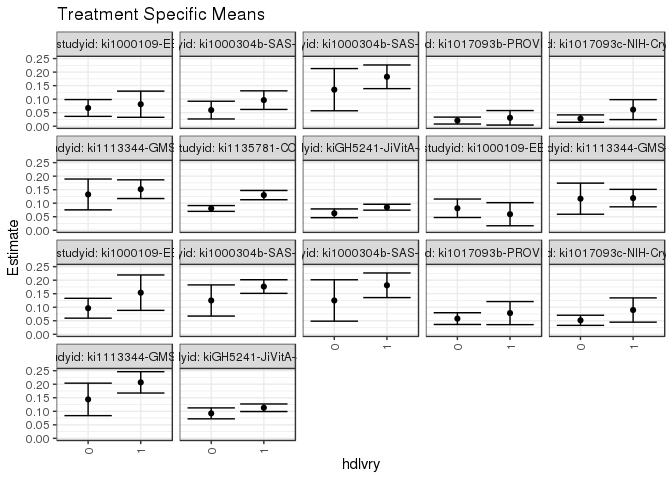

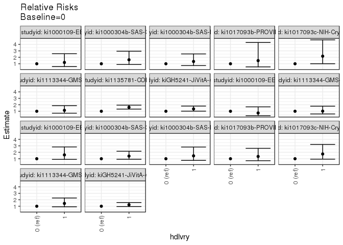

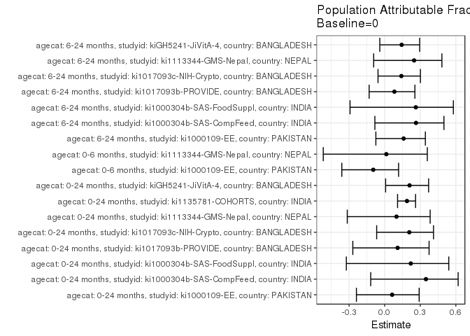

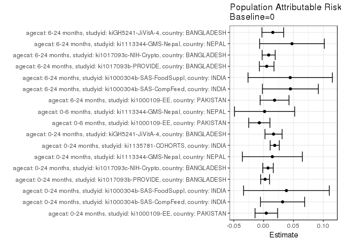

## Results Table

### Parameter: TSM

| agecat | studyid | country | intervention_level | baseline_level | estimate | ci_lower | ci_upper |
| --- | --- | --- | --- | --- | --- | --- | --- |
| 0-24 months | ki1000109-EE | PAKISTAN | 0 | NA | 0.0674603 | 0.0364515 | 0.0984692 |
| 0-24 months | ki1000109-EE | PAKISTAN | 1 | NA | 0.0813008 | 0.0329382 | 0.1296634 |
| 0-24 months | ki1000304b-SAS-CompFeed | INDIA | 0 | NA | 0.0596026 | 0.0268592 | 0.0923461 |
| 0-24 months | ki1000304b-SAS-CompFeed | INDIA | 1 | NA | 0.0963731 | 0.0619791 | 0.1307670 |
| 0-24 months | ki1000304b-SAS-FoodSuppl | INDIA | 0 | NA | 0.1351351 | 0.0571395 | 0.2131308 |
| 0-24 months | ki1000304b-SAS-FoodSuppl | INDIA | 1 | NA | 0.1827243 | 0.1390096 | 0.2264389 |
| 0-24 months | ki1017093b-PROVIDE | BANGLADESH | 0 | NA | 0.0208768 | 0.0080632 | 0.0336904 |
| 0-24 months | ki1017093b-PROVIDE | BANGLADESH | 1 | NA | 0.0310559 | 0.0042398 | 0.0578720 |
| 0-24 months | ki1017093c-NIH-Crypto | BANGLADESH | 0 | NA | 0.0282187 | 0.0145789 | 0.0418585 |
| 0-24 months | ki1017093c-NIH-Crypto | BANGLADESH | 1 | NA | 0.0613497 | 0.0244850 | 0.0982143 |
| 0-24 months | ki1113344-GMS-Nepal | NEPAL | 0 | NA | 0.1323529 | 0.0753481 | 0.1893577 |
| 0-24 months | ki1113344-GMS-Nepal | NEPAL | 1 | NA | 0.1518072 | 0.1172521 | 0.1863623 |
| 0-24 months | ki1135781-COHORTS | INDIA | 0 | NA | 0.0805397 | 0.0697540 | 0.0913253 |
| 0-24 months | ki1135781-COHORTS | INDIA | 1 | NA | 0.1299663 | 0.1128613 | 0.1470713 |
| 0-24 months | kiGH5241-JiVitA-4 | BANGLADESH | 0 | NA | 0.0626632 | 0.0465229 | 0.0788035 |
| 0-24 months | kiGH5241-JiVitA-4 | BANGLADESH | 1 | NA | 0.0851388 | 0.0742362 | 0.0960415 |
| 0-6 months | ki1000109-EE | PAKISTAN | 0 | NA | 0.0813008 | 0.0471019 | 0.1154997 |
| 0-6 months | ki1000109-EE | PAKISTAN | 1 | NA | 0.0593220 | 0.0166412 | 0.1020029 |
| 0-6 months | ki1113344-GMS-Nepal | NEPAL | 0 | NA | 0.1166667 | 0.0591728 | 0.1741606 |
| 0-6 months | ki1113344-GMS-Nepal | NEPAL | 1 | NA | 0.1188630 | 0.0865880 | 0.1511381 |
| 6-24 months | ki1000109-EE | PAKISTAN | 0 | NA | 0.0963855 | 0.0596793 | 0.1330918 |
| 6-24 months | ki1000109-EE | PAKISTAN | 1 | NA | 0.1538462 | 0.0883799 | 0.2193124 |
| 6-24 months | ki1000304b-SAS-CompFeed | INDIA | 0 | NA | 0.1250000 | 0.0674147 | 0.1825853 |
| 6-24 months | ki1000304b-SAS-CompFeed | INDIA | 1 | NA | 0.1765389 | 0.1513735 | 0.2017043 |
| 6-24 months | ki1000304b-SAS-FoodSuppl | INDIA | 0 | NA | 0.1250000 | 0.0484992 | 0.2015008 |
| 6-24 months | ki1000304b-SAS-FoodSuppl | INDIA | 1 | NA | 0.1811594 | 0.1356555 | 0.2266633 |
| 6-24 months | ki1017093b-PROVIDE | BANGLADESH | 0 | NA | 0.0580357 | 0.0363669 | 0.0797046 |
| 6-24 months | ki1017093b-PROVIDE | BANGLADESH | 1 | NA | 0.0784314 | 0.0357957 | 0.1210670 |
| 6-24 months | ki1017093c-NIH-Crypto | BANGLADESH | 0 | NA | 0.0517560 | 0.0330749 | 0.0704371 |
| 6-24 months | ki1017093c-NIH-Crypto | BANGLADESH | 1 | NA | 0.0897436 | 0.0448607 | 0.1346265 |
| 6-24 months | ki1113344-GMS-Nepal | NEPAL | 0 | NA | 0.1439394 | 0.0840007 | 0.2038781 |
| 6-24 months | ki1113344-GMS-Nepal | NEPAL | 1 | NA | 0.2068966 | 0.1674571 | 0.2463360 |
| 6-24 months | kiGH5241-JiVitA-4 | BANGLADESH | 0 | NA | 0.0922374 | 0.0720185 | 0.1124564 |
| 6-24 months | kiGH5241-JiVitA-4 | BANGLADESH | 1 | NA | 0.1130573 | 0.0990735 | 0.1270412 |

### Parameter: E(Y)

| agecat | studyid | country | intervention_level | baseline_level | estimate | ci_lower | ci_upper |
| --- | --- | --- | --- | --- | --- | --- | --- |
| 0-24 months | ki1000109-EE | PAKISTAN | NA | NA | 0.0720000 | 0.0458029 | 0.0981971 |
| 0-24 months | ki1000304b-SAS-CompFeed | INDIA | NA | NA | 0.0913978 | 0.0593363 | 0.1234594 |
| 0-24 months | ki1000304b-SAS-FoodSuppl | INDIA | NA | NA | 0.1733333 | 0.1349698 | 0.2116969 |
| 0-24 months | ki1017093b-PROVIDE | BANGLADESH | NA | NA | 0.0234375 | 0.0117074 | 0.0351676 |
| 0-24 months | ki1017093c-NIH-Crypto | BANGLADESH | NA | NA | 0.0356164 | 0.0221630 | 0.0490699 |
| 0-24 months | ki1113344-GMS-Nepal | NEPAL | NA | NA | 0.1470054 | 0.1174112 | 0.1765996 |
| 0-24 months | ki1135781-COHORTS | INDIA | NA | NA | 0.0992114 | 0.0898650 | 0.1085578 |
| 0-24 months | kiGH5241-JiVitA-4 | BANGLADESH | NA | NA | 0.0793041 | 0.0701363 | 0.0884719 |
| 0-6 months | ki1000109-EE | PAKISTAN | NA | NA | 0.0741758 | 0.0472177 | 0.1011340 |
| 0-6 months | ki1113344-GMS-Nepal | NEPAL | NA | NA | 0.1183432 | 0.0901986 | 0.1464877 |
| 6-24 months | ki1000109-EE | PAKISTAN | NA | NA | 0.1147541 | 0.0820564 | 0.1474518 |
| 6-24 months | ki1000304b-SAS-CompFeed | INDIA | NA | NA | 0.1698686 | 0.1413755 | 0.1983616 |
| 6-24 months | ki1000304b-SAS-FoodSuppl | INDIA | NA | NA | 0.1695402 | 0.1300601 | 0.2090204 |
| 6-24 months | ki1017093b-PROVIDE | BANGLADESH | NA | NA | 0.0632280 | 0.0437545 | 0.0827015 |
| 6-24 months | ki1017093c-NIH-Crypto | BANGLADESH | NA | NA | 0.0602582 | 0.0425793 | 0.0779372 |
| 6-24 months | ki1113344-GMS-Nepal | NEPAL | NA | NA | 0.1914498 | 0.1581730 | 0.2247266 |
| 6-24 months | kiGH5241-JiVitA-4 | BANGLADESH | NA | NA | 0.1076741 | 0.0959797 | 0.1193686 |

### Parameter: RR

| agecat | studyid | country | intervention_level | baseline_level | estimate | ci_lower | ci_upper |
| --- | --- | --- | --- | --- | --- | --- | --- |
| 0-24 months | ki1000109-EE | PAKISTAN | 0 | 0 | 1.000000 | 1.0000000 | 1.000000 |
| 0-24 months | ki1000109-EE | PAKISTAN | 1 | 0 | 1.205165 | 0.5682775 | 2.555833 |
| 0-24 months | ki1000304b-SAS-CompFeed | INDIA | 0 | 0 | 1.000000 | 1.0000000 | 1.000000 |
| 0-24 months | ki1000304b-SAS-CompFeed | INDIA | 1 | 0 | 1.616926 | 0.8882404 | 2.943402 |
| 0-24 months | ki1000304b-SAS-FoodSuppl | INDIA | 0 | 0 | 1.000000 | 1.0000000 | 1.000000 |
| 0-24 months | ki1000304b-SAS-FoodSuppl | INDIA | 1 | 0 | 1.352159 | 0.7239137 | 2.525626 |
| 0-24 months | ki1017093b-PROVIDE | BANGLADESH | 0 | 0 | 1.000000 | 1.0000000 | 1.000000 |
| 0-24 months | ki1017093b-PROVIDE | BANGLADESH | 1 | 0 | 1.487578 | 0.5156933 | 4.291091 |
| 0-24 months | ki1017093c-NIH-Crypto | BANGLADESH | 0 | 0 | 1.000000 | 1.0000000 | 1.000000 |
| 0-24 months | ki1017093c-NIH-Crypto | BANGLADESH | 1 | 0 | 2.174080 | 1.0054462 | 4.701020 |
| 0-24 months | ki1113344-GMS-Nepal | NEPAL | 0 | 0 | 1.000000 | 1.0000000 | 1.000000 |
| 0-24 months | ki1113344-GMS-Nepal | NEPAL | 1 | 0 | 1.146988 | 0.7046784 | 1.866924 |
| 0-24 months | ki1135781-COHORTS | INDIA | 0 | 0 | 1.000000 | 1.0000000 | 1.000000 |
| 0-24 months | ki1135781-COHORTS | INDIA | 1 | 0 | 1.613694 | 1.3374458 | 1.947000 |
| 0-24 months | kiGH5241-JiVitA-4 | BANGLADESH | 0 | 0 | 1.000000 | 1.0000000 | 1.000000 |
| 0-24 months | kiGH5241-JiVitA-4 | BANGLADESH | 1 | 0 | 1.358674 | 1.0210158 | 1.807999 |
| 0-6 months | ki1000109-EE | PAKISTAN | 0 | 0 | 1.000000 | 1.0000000 | 1.000000 |
| 0-6 months | ki1000109-EE | PAKISTAN | 1 | 0 | 0.729661 | 0.3170816 | 1.679080 |
| 0-6 months | ki1113344-GMS-Nepal | NEPAL | 0 | 0 | 1.000000 | 1.0000000 | 1.000000 |
| 0-6 months | ki1113344-GMS-Nepal | NEPAL | 1 | 0 | 1.018826 | 0.5804169 | 1.788381 |
| 6-24 months | ki1000109-EE | PAKISTAN | 0 | 0 | 1.000000 | 1.0000000 | 1.000000 |
| 6-24 months | ki1000109-EE | PAKISTAN | 1 | 0 | 1.596154 | 0.9017123 | 2.825410 |
| 6-24 months | ki1000304b-SAS-CompFeed | INDIA | 0 | 0 | 1.000000 | 1.0000000 | 1.000000 |
| 6-24 months | ki1000304b-SAS-CompFeed | INDIA | 1 | 0 | 1.412311 | 0.9221162 | 2.163093 |
| 6-24 months | ki1000304b-SAS-FoodSuppl | INDIA | 0 | 0 | 1.000000 | 1.0000000 | 1.000000 |
| 6-24 months | ki1000304b-SAS-FoodSuppl | INDIA | 1 | 0 | 1.449275 | 0.7479025 | 2.808386 |
| 6-24 months | ki1017093b-PROVIDE | BANGLADESH | 0 | 0 | 1.000000 | 1.0000000 | 1.000000 |
| 6-24 months | ki1017093b-PROVIDE | BANGLADESH | 1 | 0 | 1.351433 | 0.6988545 | 2.613378 |
| 6-24 months | ki1017093c-NIH-Crypto | BANGLADESH | 0 | 0 | 1.000000 | 1.0000000 | 1.000000 |
| 6-24 months | ki1017093c-NIH-Crypto | BANGLADESH | 1 | 0 | 1.733974 | 0.9357996 | 3.212939 |
| 6-24 months | ki1113344-GMS-Nepal | NEPAL | 0 | 0 | 1.000000 | 1.0000000 | 1.000000 |
| 6-24 months | ki1113344-GMS-Nepal | NEPAL | 1 | 0 | 1.437387 | 0.9092392 | 2.272318 |
| 6-24 months | kiGH5241-JiVitA-4 | BANGLADESH | 0 | 0 | 1.000000 | 1.0000000 | 1.000000 |
| 6-24 months | kiGH5241-JiVitA-4 | BANGLADESH | 1 | 0 | 1.225720 | 0.9542728 | 1.574383 |

### Parameter: PAR

| agecat | studyid | country | intervention_level | baseline_level | estimate | ci_lower | ci_upper |
| --- | --- | --- | --- | --- | --- | --- | --- |
| 0-24 months | ki1000109-EE | PAKISTAN | 0 | NA | 0.0045397 | -0.0143154 | 0.0233947 |
| 0-24 months | ki1000304b-SAS-CompFeed | INDIA | 0 | NA | 0.0317952 | -0.0051651 | 0.0687555 |
| 0-24 months | ki1000304b-SAS-FoodSuppl | INDIA | 0 | NA | 0.0381982 | -0.0335945 | 0.1099909 |
| 0-24 months | ki1017093b-PROVIDE | BANGLADESH | 0 | NA | 0.0025607 | -0.0049237 | 0.0100450 |
| 0-24 months | ki1017093c-NIH-Crypto | BANGLADESH | 0 | NA | 0.0073977 | -0.0014360 | 0.0162315 |
| 0-24 months | ki1113344-GMS-Nepal | NEPAL | 0 | NA | 0.0146525 | -0.0355594 | 0.0648644 |
| 0-24 months | ki1135781-COHORTS | INDIA | 0 | NA | 0.0186717 | 0.0109961 | 0.0263474 |
| 0-24 months | kiGH5241-JiVitA-4 | BANGLADESH | 0 | NA | 0.0166409 | 0.0023182 | 0.0309636 |
| 0-6 months | ki1000109-EE | PAKISTAN | 0 | NA | -0.0071250 | -0.0248864 | 0.0106364 |
| 0-6 months | ki1113344-GMS-Nepal | NEPAL | 0 | NA | 0.0016765 | -0.0486515 | 0.0520045 |
| 6-24 months | ki1000109-EE | PAKISTAN | 0 | NA | 0.0183686 | -0.0057812 | 0.0425184 |
| 6-24 months | ki1000304b-SAS-CompFeed | INDIA | 0 | NA | 0.0448686 | -0.0018925 | 0.0916296 |
| 6-24 months | ki1000304b-SAS-FoodSuppl | INDIA | 0 | NA | 0.0445402 | -0.0260953 | 0.1151758 |
| 6-24 months | ki1017093b-PROVIDE | BANGLADESH | 0 | NA | 0.0051922 | -0.0070039 | 0.0173883 |
| 6-24 months | ki1017093c-NIH-Crypto | BANGLADESH | 0 | NA | 0.0085022 | -0.0024421 | 0.0194466 |
| 6-24 months | ki1113344-GMS-Nepal | NEPAL | 0 | NA | 0.0475104 | -0.0066842 | 0.1017051 |
| 6-24 months | kiGH5241-JiVitA-4 | BANGLADESH | 0 | NA | 0.0154367 | -0.0026911 | 0.0335645 |

### Parameter: PAF

| agecat | studyid | country | intervention_level | baseline_level | estimate | ci_lower | ci_upper |
| --- | --- | --- | --- | --- | --- | --- | --- |
| 0-24 months | ki1000109-EE | PAKISTAN | 0 | NA | 0.0630511 | -0.2379464 | 0.2908634 |
| 0-24 months | ki1000304b-SAS-CompFeed | INDIA | 0 | NA | 0.3478769 | -0.1175046 | 0.6194516 |
| 0-24 months | ki1000304b-SAS-FoodSuppl | INDIA | 0 | NA | 0.2203742 | -0.3229179 | 0.5405487 |
| 0-24 months | ki1017093b-PROVIDE | BANGLADESH | 0 | NA | 0.1092554 | -0.2683734 | 0.3744540 |
| 0-24 months | ki1017093c-NIH-Crypto | BANGLADESH | 0 | NA | 0.2077059 | -0.0672795 | 0.4118411 |
| 0-24 months | ki1113344-GMS-Nepal | NEPAL | 0 | NA | 0.0996732 | -0.3151219 | 0.3836401 |
| 0-24 months | ki1135781-COHORTS | INDIA | 0 | NA | 0.1882016 | 0.1088814 | 0.2604613 |
| 0-24 months | kiGH5241-JiVitA-4 | BANGLADESH | 0 | NA | 0.2098369 | 0.0082102 | 0.3704737 |
| 0-6 months | ki1000109-EE | PAKISTAN | 0 | NA | -0.0960554 | -0.3610553 | 0.1173486 |
| 0-6 months | ki1113344-GMS-Nepal | NEPAL | 0 | NA | 0.0141667 | -0.5175618 | 0.3595863 |
| 6-24 months | ki1000109-EE | PAKISTAN | 0 | NA | 0.1600688 | -0.0740890 | 0.3431789 |
| 6-24 months | ki1000304b-SAS-CompFeed | INDIA | 0 | NA | 0.2641369 | -0.0824334 | 0.4997434 |
| 6-24 months | ki1000304b-SAS-FoodSuppl | INDIA | 0 | NA | 0.2627119 | -0.2917963 | 0.5791954 |
| 6-24 months | ki1017093b-PROVIDE | BANGLADESH | 0 | NA | 0.0821194 | -0.1307393 | 0.2549079 |
| 6-24 months | ki1017093c-NIH-Crypto | BANGLADESH | 0 | NA | 0.1410967 | -0.0559235 | 0.3013558 |
| 6-24 months | ki1113344-GMS-Nepal | NEPAL | 0 | NA | 0.2481612 | -0.0924812 | 0.4825892 |
| 6-24 months | kiGH5241-JiVitA-4 | BANGLADESH | 0 | NA | 0.1433649 | -0.0410189 | 0.2950910 |